# Microproyecto 2: clasificación de textos según los Objetivos de Desarrollo Sostenible

**Universidad:** Universidad de Los Andes

**Programa:** Maestría en Inteligencia Artificial Aplicada

**Asignatura:** Machine Learning No Supervisado

**Periodo:** 2026

**Estudiantes:** Oscar Ferney Gallo - Andrés Felipe Becerra Puerto

## 1. Presentación del proyecto

### 1.1. Objetivo

Desarrollar una solución basada en procesamiento de lenguaje natural y machine learning que facilite la identificación de relaciones semánticas entre textos en español y los Objetivos de Desarrollo Sostenible, mediante una representación TF-IDF, un modelo de tópicos LSA y un modelo de clasificación multiclase.

### 1.2. Metodología propuesta:

El proyecto seguirá una secuencia que mantiene separado el conjunto de prueba hasta la evaluación final:

1. **Comprensión de los datos:** revisión de variables, etiquetas y calidad.
2. **Exploración:** distribución de clases, longitud y contenido de los textos.
3. **División de los datos:** entrenamiento y prueba mediante muestreo estratificado.
4. **Representación:** limpieza y ponderación TF-IDF dentro de un pipeline.
5. **Análisis no supervisado:** reducción mediante TruncatedSVD e interpretación de tópicos LSA.
6. **Clasificación:** ajuste del modelo y búsqueda de hiperparámetros usando solamente entrenamiento.
7. **Evaluación:** métricas multiclase, matriz de confusión y revisión de textos de prueba.

## 2. Preparación del entorno

### 2.1. Importación de librerías

Se importan herramientas para manipular datos, construir expresiones regulares y elaborar las visualizaciones exploratorias. También se fija una semilla para que los procedimientos posteriores puedan reproducirse.

```python
from pathlib import Path
import re
import textwrap

import numpy as np
import pandas as pd
import matplotlib.pyplot as plt
import seaborn as sns

import nltk

from scipy.stats import loguniform, randint, uniform
from sklearn.decomposition import TruncatedSVD
from sklearn.feature_extraction.text import TfidfVectorizer
from sklearn.metrics import (
    accuracy_score,
    classification_report,
    f1_score,
    precision_score,
    recall_score,
)
from sklearn.model_selection import RandomizedSearchCV, StratifiedKFold, train_test_split
from sklearn.pipeline import Pipeline
from sklearn.svm import LinearSVC

# Semilla global para obtener resultados reproducibles
RANDOM_STATE = 42
```

### 2.2. Nombres de los ODS

Para efectos de interpretación en el desarrollo del microproyecto, se define un diccionario con el número y nombre de cada ODS, permitiendo que las tablas y gráficas sean más fáciles de interpretar que una presentación basada solo en números.

```python
nombres_ods = {
    1: "Fin de la pobreza",
    2: "Hambre cero",
    3: "Salud y bienestar",
    4: "Educación de calidad",
    5: "Igualdad de género",
    6: "Agua limpia y saneamiento",
    7: "Energía asequible y no contaminante",
    8: "Trabajo decente y crecimiento económico",
    9: "Industria, innovación e infraestructura",
    10: "Reducción de las desigualdades",
    11: "Ciudades y comunidades sostenibles",
    12: "Producción y consumo responsables",
    13: "Acción por el clima",
    14: "Vida submarina",
    15: "Vida de ecosistemas terrestres",
    16: "Paz, justicia e instituciones sólidas",
    17: "Alianzas para lograr los objetivos",
}

nombres_ods
```

```
{1: 'Fin de la pobreza',
 2: 'Hambre cero',
 3: 'Salud y bienestar',
 4: 'Educación de calidad',
 5: 'Igualdad de género',
 6: 'Agua limpia y saneamiento',
 7: 'Energía asequible y no contaminante',
 8: 'Trabajo decente y crecimiento económico',
 9: 'Industria, innovación e infraestructura',
 10: 'Reducción de las desigualdades',
 11: 'Ciudades y comunidades sostenibles',
 12: 'Producción y consumo responsables',
 13: 'Acción por el clima',
 14: 'Vida submarina',
 15: 'Vida de ecosistemas terrestres',
 16: 'Paz, justicia e instituciones sólidas',
 17: 'Alianzas para lograr los objetivos'}
```

## 3. Carga y comprensión de los datos

### 3.1. Carga del conjunto de datos

```python
ruta = Path("Datos_textosODS.xlsx")
datos = pd.read_excel(ruta)

print(f"Número de filas: {datos.shape[0]:,}")
print(f"Número de columnas: {datos.shape[1]}")
print(f"Nombre de columnas: {datos.columns}")
```

```
Número de filas: 9,656
Número de columnas: 2
Nombre de columnas: Index(['textos', 'ODS'], dtype='object')
```

### 3.2. Vista inicial

Se muestran tres registros abreviados. La abreviación en la cantidad de caracteres se utiliza únicamente para facilitar la lectura de la salida y se entiende que los textos completos están en el dataset llamado datos.

```python
# Función para limitar la cantidad de caracteres de los textos para hacer una vista inicial exploratoria
def abreviar_texto(texto, longitud = 180):
    texto = str(texto)
    return texto if len(texto) <= longitud else texto[:longitud].rstrip() + "..."

vista_inicial = datos.head(3).copy()
vista_inicial["textos"] = vista_inicial["textos"].apply(abreviar_texto)

print(vista_inicial.to_string(index=False))
```

```
                                                                                                                                                                                 textos  ODS
"Aprendizaje" y "educación" se consideran sinónimos de escolarización formal. Las organizaciones auxiliares, como las editoriales de educación, las juntas examinadoras y las organi...    4
 No dejar clara la naturaleza de estos riesgos puede dar lugar a un exceso de inversión en empresas dependientes del agua y a peticiones de compensación cuando haya que reducir los...    6
Como resultado, un mayor y mejorado acceso al agua puede afectar aún más la capacidad de adaptación y resiliencia de las comunidades al cambio climático. Para la adaptación, muchos...   13
```

### 3.3. Verificación de las etiquetas disponibles y no disponibles

Teniendo en cuenta que la capacidad real del modelo depende de las etiquetas presentes en el archivo, se realiza una exploración de las etiquetas presentes y ausentes para identificar posibles limitaciones del modelo.

```python
ods_observados = sorted(datos["ODS"].unique().tolist())
ods_esperados = list(range(1, 18))
ods_ausentes = sorted(set(ods_esperados) - set(ods_observados))

print(f"ODS observados ({len(ods_observados)}): {ods_observados}")
print(f"ODS ausentes: {ods_ausentes}")
```

```
ODS observados (16): [1, 2, 3, 4, 5, 6, 7, 8, 9, 10, 11, 12, 13, 14, 15, 16]
ODS ausentes: [17]
```

El conjunto suministrado contiene observaciones para los ODS 1 a 16, pero no incluye textos etiquetados como ODS 17. En consecuencia, el modelo construido con esta base podrá diferenciar 16 categorías. Con base en esto, el modelo solo podrá aprender las categorías que tienen ejemplos en el conjunto de datos.

## 4. Análisis exploratorio y calidad de los datos

### 4.1. Tipos de datos, valores faltantes y textos vacíos

Primero se comprueba si existen valores faltantes o cadenas vacías. Un texto vacío no puede transformarse en información útil mediante TF-IDF y tendría que excluirse o tratarse explícitamente.

```python
# Resumen de la calidad de las variables
resumen_calidad = pd.DataFrame({
    "Tipo de dato": datos.dtypes.astype(str),
    "Datos faltantes": datos.isna().sum(),
    "Datos únicos": datos.nunique(),
})

# Comprobar si existen textos formados únicamente por espacios
textos_vacios = datos["textos"].astype(str).str.strip().eq("").sum()

print(resumen_calidad)
print(f"\nTextos vacíos: {textos_vacios}")
```

```
       Tipo de dato  Datos faltantes  Datos únicos
textos       object                0          9656
ODS           int64                0            16

Textos vacíos: 0
```

Las dos variables están completas y no se encontraron textos vacíos. Esto permite continuar sin imputar valores ni eliminar registros por ausencia de información.

### 4.2. Revisión de datos duplicados

Antes de continuar, se verifica si alguna fila o algún texto aparece más de una vez. Los registros que tengan duplicidad podrían dar mayor importancia a ciertos textos durante el entrenamiento y afectar la evaluación del modelo.

```python
#Se evalúan si hay filas duplicadas en su totalidad
duplicados_filas = datos.duplicated().sum()

#Se evalúan si hay textos duplicados
duplicados_textos = datos["textos"].duplicated().sum()

print(f"Filas duplicadas: {duplicados_filas}")
print(f"Textos duplicados: {duplicados_textos}")
```

```
Filas duplicadas: 0
Textos duplicados: 0
```

No se encontraron filas ni textos duplicados. Por esta razón, no es necesario eliminar registros en esta etapa.

### 4.3. Distribución de textos por ODS

Se realiza una gráfica de barras para explorar el balance de los datos y saber si todas las clases tienen entre sí cantidad semejante de datos.

```
ODS
1      505
2      369
3      894
4     1025
5     1070
6      695
7      787
8      446
9      343
10     352
11     607
12     312
13     464
14     377
15     330
16    1080
Name: count, dtype: int64
```

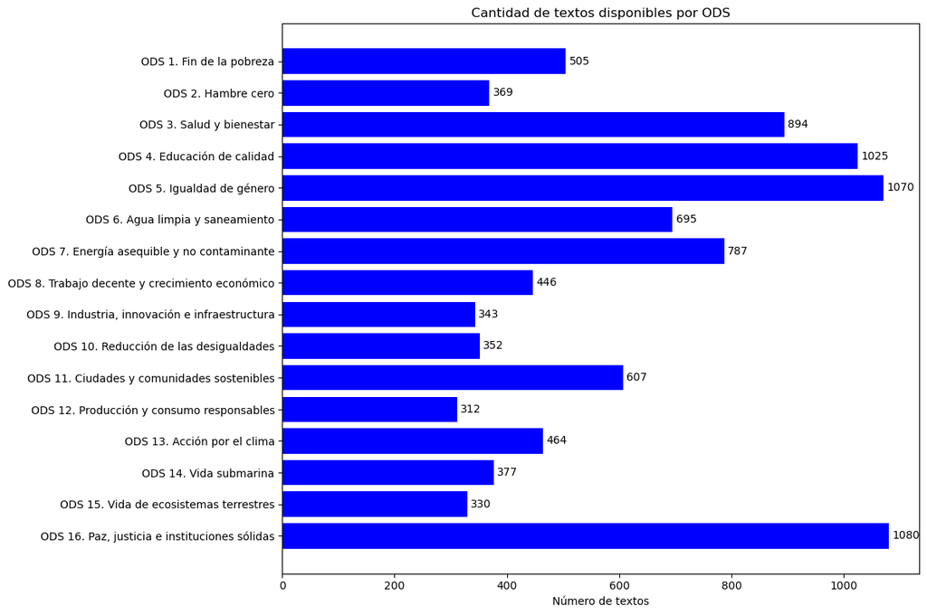

```python
# Contar cuántos textos corresponden a cada ODS
conteo_ods = datos["ODS"].value_counts().sort_index()

print(conteo_ods)

# Crear las etiquetas con el número y el nombre del ODS
etiquetas = [
    f"ODS {ods}. {nombres_ods[ods]}"
    for ods in conteo_ods.index
]

# Construir la gráfica
plt.figure(figsize = (12, 8))

barras = plt.barh(etiquetas, conteo_ods.values, color = "blue")


plt.bar_label(barras, padding=3)
plt.title("Cantidad de textos disponibles por ODS")
plt.xlabel("Número de textos")
plt.ylabel("")
plt.gca().invert_yaxis()
plt.tight_layout()
plt.show()
```

La distribución presenta un desbalance a tener en cuenta. Los ODS 4, 5 y 16 tienen más de mil textos, mientras que los ODS 9, 12 y 15 tienen menos de 350. Por esta razón, el desempeño no se evaluará únicamente con exactitud; también se utilizará F1 macro para dar el mismo peso a cada ODS.

### 4.4. Longitud de los textos

La longitud de los textos se calcula a partir de su número de palabras. Esta revisión permite identificar si existen textos demasiado cortos o extensos y conocer las características generales de los textos que serán utilizados por el modelo.

```
count    9656.000000
mean      111.017295
std        37.082212
min        24.000000
25%        82.000000
50%       105.000000
75%       135.000000
max       268.000000
Name: textos, dtype: float64
```

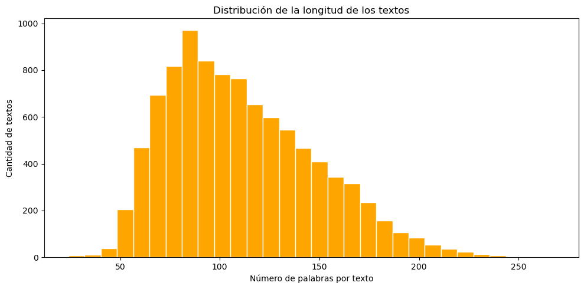

```python
# Contar el número de palabras de cada texto
cantidad_palabras = datos["textos"].apply(
    lambda texto: len(texto.split()))

# Mostrar las principales estadísticas de la longitud de los textos
print(cantidad_palabras.describe())

# Construir el histograma
plt.figure(figsize = (10, 5))
plt.hist(cantidad_palabras, bins = 30, color = "orange", edgecolor ="white")

# Agregar los títulos de la gráfica
plt.title("Distribución de la longitud de los textos")
plt.xlabel("Número de palabras por texto")
plt.ylabel("Cantidad de textos")

plt.tight_layout()
plt.show()
```

En promedio, los textos contienen aproximadamente 111 palabras. El texto más corto tiene 24 palabras y el más largo 268. En general, no se observan textos excesivamente cortos o extensos, por lo que no es necesario limitar su longitud antes de aplicar TF-IDF.

### 4.5. Longitud de los textos según el ODS

Al realizar una gráfica tipo diagrama de cajas, se puede comparar la cantidad de palabras de los textos correspondientes a cada ODS. Esto ayuda a identificar si algunos ODS contienen textos generalmente más cortos o más extensos.

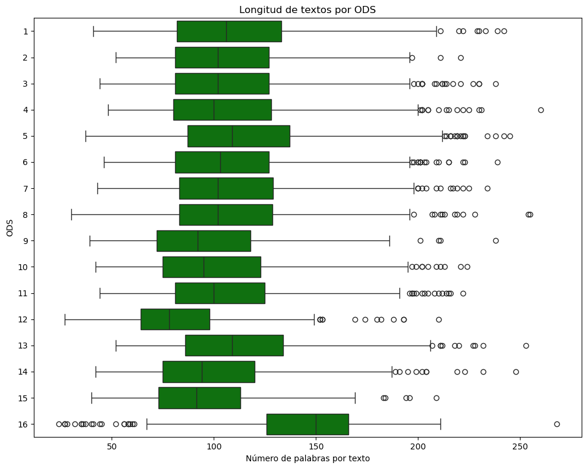

```python
# Agregar al conjunto de datos el número de palabras calculado anteriormente
datos["n_palabras"] = cantidad_palabras

# Configuración de la gráfica para poder comparar entre ODS
plt.figure(figsize=(10, 8))
sns.boxplot(data=datos, x = "n_palabras", y = "ODS", orient = "h", color = "green")

# Agregar los títulos de la gráfica
plt.title("Longitud de textos por ODS")
plt.xlabel("Número de palabras por texto")
plt.ylabel("ODS")

plt.tight_layout()
plt.show()
```

Aunque se presentan algunas diferencias en la longitud de los textos, los rangos de los ODS se superponen. Por esto, la longitud por sí sola no parece suficiente para diferenciar las categorías; el modelo deberá apoyarse principalmente en las palabras y relaciones semánticas de cada texto.

### 4.6. Revisión de posible ruido o fuga de información

Finalmente, se verifica si los textos contienen direcciones web o menciones directas a un ODS específico. Estos elementos podrían introducir ruido o facilitar artificialmente la clasificación.

```python
# Usar las mismas expresiones que se aplicarán durante la limpieza
patron_url = r"https?://\S+|www\.\S+"
patron_ods = r"ods\s*\d+"

textos_con_url = datos["textos"].str.contains(
    patron_url, case=False, regex=True
).sum()

textos_con_numero_ods = datos["textos"].str.contains(
    patron_ods, case=False, regex=True
).sum()

print(f"Textos con direcciones web: {textos_con_url}")
print(f"Textos que mencionan un ODS específico: {textos_con_numero_ods}")
```

```
Textos con direcciones web: 67
Textos que mencionan un ODS específico: 45
```

La revisión muestra que una parte pequeña de los textos contiene direcciones web o menciones a un ODS específico. Estos elementos se retirarán durante el preprocesamiento, pero los textos se conservarán porque el resto de su contenido aporta información temática.

# 5. Preparación de los textos

## 5.1. Separación de las variables

La columna `textos` contiene la información que utilizará el modelo para aprender. La columna `ODS` contiene la categoría que se desea predecir.

```python
# Separar los textos y la variable objetivo
X = datos["textos"]
y = datos["ODS"]

print(f"Número de textos: {len(X):,}")
print(f"Número de categorías: {y.nunique()}")
```

```
Número de textos: 9,656
Número de categorías: 16
```

## 5.2. División entre entrenamiento y prueba

Se usa el 20 % de los textos para evaluar el modelo al final. El argumento stratify=y conserva una proporción semejante de cada ODS en ambos conjuntos buscando el mejor balance de los datos. La semilla 42 permite obtener la misma división al repetir el procedimiento.

Esta división se realiza antes de construir TF-IDF y SVD. De esta manera, el vocabulario y la reducción de dimensionalidad se aprenden únicamente con los textos de entrenamiento.

```python
# Dividir los datos conservando la distribución de los ODS
X_train, X_test, y_train, y_test = train_test_split(X, y, test_size = 0.20, random_state = RANDOM_STATE, stratify = y)

print(f"Textos de entrenamiento: {len(X_train):,}")
print(f"Textos de prueba: {len(X_test):,}")
```

```
Textos de entrenamiento: 7,724
Textos de prueba: 1,932
```

## 5.3. Preparación básica de los textos

La función **limpiar_texto()** realiza tres tareas:

1. Convierte el texto a minúsculas.
2. Elimina direcciones web.
3. Elimina referencias directas como **ods 6** u **objetivo de desarrollo sostenible 6** para reducir el riesgo de que el modelo encuentre la respuesta escrita en el texto.

```python
# Función utilizada para limpiar cada texto
def limpiar_texto(texto):
    texto = texto.lower()

    # Eliminar direcciones web
    texto = re.sub(r"https?://\S+|www\.\S+", " ", texto)

    # Eliminar referencias directas al número de un ODS
    texto = re.sub(r"ods\s*\d+", " ", texto)
    texto = re.sub(
        r"objetivo(?:s)? de desarrollo sostenible\s*\d+",
        " ",
        texto,
    )
    texto = re.sub(r"objetivo\s+\d+", " ", texto)

    return texto


# Palabras frecuentes que no ayudan a diferenciar los temas ()
nltk.download('stopwords', quiet=True)
palabras_vacias = nltk.corpus.stopwords.words('spanish')

ejemplo_original = X_train.iloc[0]
ejemplo_limpio = limpiar_texto(ejemplo_original)

print("Ejemplo antes de la limpieza:")
print(ejemplo_original[:300])
print("\nEjemplo después de la limpieza:")
print(ejemplo_limpio[:300])
```

```
Ejemplo antes de la limpieza:
Por lo tanto, cabe esperar que el aumento de los niveles de ingresos posterior a la reforma de la asistencia social, tanto para los que tienen trabajo como para los que no tienen, tenga un efecto positivo en los niños. Una revisión de la evidencia sobre la reforma del bienestar y los resultados de l

Ejemplo después de la limpieza:
por lo tanto, cabe esperar que el aumento de los niveles de ingresos posterior a la reforma de la asistencia social, tanto para los que tienen trabajo como para los que no tienen, tenga un efecto positivo en los niños. una revisión de la evidencia sobre la reforma del bienestar y los resultados de l
```

## 5.4. Representación mediante TF-IDF

Una bolsa de palabras representa cada texto según los términos que contiene. TF-IDF complementa esta representación asignando mayor importancia a las palabras frecuentes dentro de un texto, pero menos comunes en el conjunto completo.

Para construir la representación TF-IDF se eliminan las palabras vacías y se conservan los términos presentes en al menos tres textos, pero no en más del 90 % de los textos. Se incluyen palabras individuales y combinaciones de dos palabras para representar expresiones como “cambio climático” o “agua potable”. Finalmente, el vocabulario se limita a 15.000 términos para controlar el tamaño de la matriz y facilitar la aplicación de LSA.

```python
# se declara el objeto que se empleará más adelante para aplicar la transformación TF-IDF en nuestros pipelines
vectorizador_lsa = TfidfVectorizer(
    preprocessor = limpiar_texto,
    stop_words = palabras_vacias,
    min_df = 3,
    max_df = 0.90,
    ngram_range = (1, 2),
    max_features = 15000,
)
```

# 6. Análisis semántico latente

## 6.1. ¿Qué es LSA?

El análisis semántico latente (LSA) aplica una reducción de dimensionalidad sobre la matriz TF-IDF. Su propósito es representar los documentos mediante un número menor de componentes que resumen relaciones entre palabras que suelen aparecer en contextos semejantes.

En este proyecto LSA tendrá dos usos diferentes:

1. **Uso predictivo:** sus componentes formarán parte del pipeline del clasificador. La cantidad se seleccionará mediante validación cruzada según el F1 macro.
2. **Uso interpretativo:** posteriormente se construirá un modelo más pequeño para examinar cinco componentes temáticos de forma comprensible.

Inicialmente se define un objeto con 100 componentes. Este valor será reemplazado durante la búsqueda de hiperparámetros.

```python
lsa_obj = TruncatedSVD(n_components = 100, random_state = RANDOM_STATE)
```

# 7. Elección del algoritmo de clasificación

El problema tiene 7.724 textos de entrenamiento y 16 clases. Para la clasificación se utiliza `LinearSVC`, un algoritmo apropiado para matrices de texto con muchas variables.

Este modelo busca una separación lineal entre las clases manteniendo un margen amplio. Además, incorpora regularización para controlar la complejidad del modelo. Su principal hiperparámetro es `C`:

- valores pequeños aplican una regularización más fuerte;
- valores grandes aplican una regularización más débil.

La combinación de eficiencia, regularización y buen funcionamiento con matrices dispersas hace que sea una alternativa razonable para este proyecto.

```python
lSVC_model = LinearSVC(C = 0.1)
```

# 8. Entrenamiento y búsqueda de hiperparámetros

## 8.1. Construcción del pipeline

El pipeline integra todos los pasos que deben aprenderse a partir de los datos:

1. Limpieza y representación TF-IDF.
2. Reducción mediante LSA.
3. Clasificación con `LinearSVC`.

Al incluir estos pasos dentro del pipeline, cada partición de la validación cruzada aprende su propio vocabulario y su propia reducción, evitando utilizar información de los datos empleados para validar.

```python
#Definición de pipeline
pipeline_txt = Pipeline(steps=[
    ("vectorizador", vectorizador_lsa),
    ("lsa", lsa_obj),
    ("clasificador", lSVC_model)
])
```

## 8.2. Búsqueda de hiperparámetros

Se utiliza una búsqueda aleatoria porque permite explorar diferentes configuraciones sin evaluar todas las combinaciones posibles. Se prueban parámetros de TF-IDF, LSA y `LinearSVC`.

La evaluación utiliza validación cruzada estratificada de cinco particiones y **F1 macro** como métrica principal. Esta métrica calcula el F1 de cada ODS y luego obtiene un promedio en el que todas las categorías tienen el mismo peso.

```python
# espacio para evaluacion de hiperparametros
# (algunos son evientemente discretos, por eso se dejan como listas predefinidas)
param_dist = {
    # TF-IDF
    "vectorizador__ngram_range": [
        (1, 1),
        (1, 2),
    ],
    "vectorizador__min_df": randint(1, 6),
    "vectorizador__max_df": uniform(0.85, 0.15),
    "vectorizador__sublinear_tf": [True, False],

    # LSA
    "lsa__n_components": randint(50, 301),

    # LinearSVC
    "clasificador__C": loguniform(1e-3, 1e2),
    "clasificador__class_weight": [
        None,
        "balanced",
    ],
}

#se define el objeto de búsqueda aleatoria con validación cruzada estratificada
random_search = RandomizedSearchCV(
    estimator=pipeline_txt,
    param_distributions=param_dist,
    n_iter=30,
    scoring="f1_macro",
    n_jobs=-1,
    cv=StratifiedKFold(n_splits=5, shuffle=True, random_state=RANDOM_STATE),
    verbose=1,
    random_state=RANDOM_STATE,
)

#>>>>><<<<<#
#---A ENTRENAR!!!
random_search.fit(X_train, y_train)
#>>>>><<<<<#
```

```
Fitting 5 folds for each of 30 candidates, totalling 150 fits
```

[output not shown]

#### Diez mejores configuraciones de la búsqueda aleatoria

```python
results_rsearch_df = pd.DataFrame(random_search.cv_results_).sort_values(by = "rank_test_score")
results_rsearch_df[['rank_test_score', 'mean_fit_time', 'mean_score_time', 'param_clasificador__C', 'param_clasificador__class_weight',
                    'param_lsa__n_components', 'param_vectorizador__max_df', 'param_vectorizador__min_df', 'mean_test_score',
                    'std_test_score', 'param_vectorizador__ngram_range']].head(10)
```

|  | rank_test_score | mean_fit_time | mean_score_time | param_clasificador__C | param_clasificador__class_weight | param_lsa__n_components | param_vectorizador__max_df | param_vectorizador__min_df | mean_test_score | std_test_score | param_vectorizador__ngram_range |
| --- | --- | --- | --- | --- | --- | --- | --- | --- | --- | --- | --- |
| 21 | 1 | 46.307832 | 1.265230 | 0.349023 | balanced | 278 | 0.887394 | 5 | 0.844911 | 0.008300 | (1, 1) |
| 20 | 2 | 44.117635 | 1.960839 | 0.137311 | balanced | 173 | 0.866184 | 1 | 0.835426 | 0.010112 | (1, 2) |
| 28 | 3 | 34.507187 | 0.716400 | 0.392603 | None | 229 | 0.904544 | 1 | 0.834695 | 0.009713 | (1, 2) |
| 17 | 4 | 48.793556 | 1.486423 | 0.045133 | balanced | 296 | 0.896647 | 5 | 0.833975 | 0.007122 | (1, 1) |
| 25 | 5 | 45.765489 | 0.910308 | 0.060463 | balanced | 274 | 0.890820 | 3 | 0.833806 | 0.005122 | (1, 2) |
| 12 | 6 | 58.142577 | 2.842905 | 0.042330 | balanced | 286 | 0.890702 | 5 | 0.832562 | 0.008500 | (1, 2) |
| 2 | 7 | 30.644117 | 1.973069 | 3.470267 | balanced | 102 | 0.995486 | 4 | 0.828803 | 0.009682 | (1, 2) |
| 23 | 8 | 31.808028 | 1.743185 | 44.513143 | None | 111 | 0.945011 | 4 | 0.828153 | 0.010874 | (1, 2) |
| 4 | 9 | 57.286262 | 2.178070 | 0.144453 | None | 268 | 0.941778 | 2 | 0.827047 | 0.007698 | (1, 2) |
| 19 | 10 | 51.382534 | 1.466874 | 17.561804 | None | 267 | 0.885398 | 3 | 0.824386 | 0.006379 | (1, 1) |

## 8.3. Análisis de los resultados de entrenamiento

### 8.3.1. Comportamiento del número de componentes

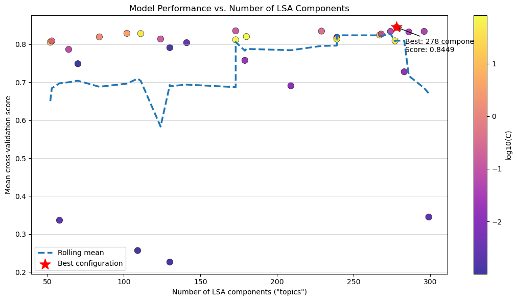

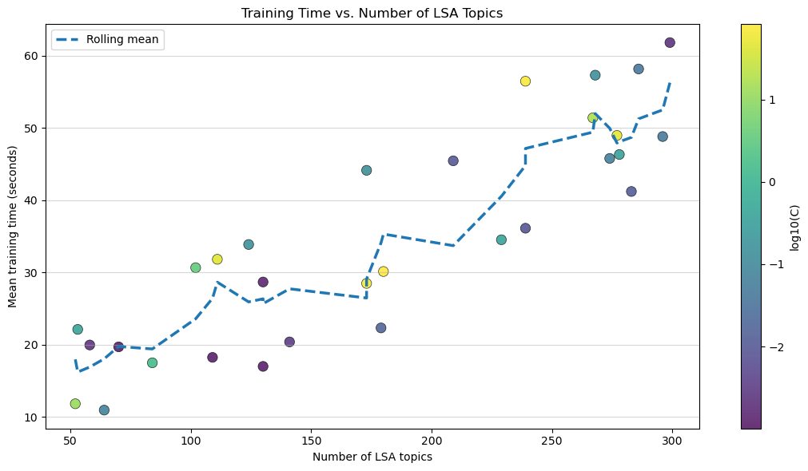

```python
def plot_lsa_results(results_df, metric = "score", rolling_window = 5, cmap = "plasma"):
    df = results_df.copy()
    df["n_components"] = df["param_lsa__n_components"].astype(int)
    df["C"] = df["param_clasificador__C"].astype(float)
    df = df.sort_values("n_components")

    cfg = {
        "score": ("mean_test_score", "Mean cross-validation score",
                  "Model Performance vs. Number of LSA Components",
                  'Number of LSA components ("topics")'),
        "time": ("mean_fit_time", "Mean training time (seconds)",
                 "Training Time vs. Number of LSA Topics",
                 "Number of LSA topics")
    }

    if metric not in cfg:
        raise ValueError("metric must be 'score' or 'time'")

    y, ylabel, title, xlabel = cfg[metric]
    rolling = df[y].rolling(rolling_window, center=True, min_periods=1).mean()
    best = df.loc[df["mean_test_score"].idxmax()]

    fig, ax = plt.subplots(figsize = (11, 6))
    sc = ax.scatter(df["n_components"], df[y], c = np.log10(df["C"]),
                    cmap = cmap, s = 80, alpha = .8, edgecolors = "black", linewidths=.5)

    ax.plot(df["n_components"], rolling, "--", lw = 2.5, label = "Rolling mean")

    if metric == "score":
        ax.scatter(best["n_components"], best[y], color = "red", marker = "*", s=250,
                   label="Best configuration", zorder = 5)
        ax.annotate(f'Best: {best["n_components"]} components\nScore: {best[y]:.4f}',
                    (best["n_components"], best[y]), xytext = (12, -35),
                    textcoords = "offset points", arrowprops = {"arrowstyle": "->"})

    ax.set(title=title, xlabel = xlabel, ylabel = ylabel)
    fig.colorbar(sc, ax = ax, label = "log10(C)")
    ax.grid(axis = "y", alpha = .5)
    ax.legend()
    plt.tight_layout()
    plt.show()


plot_lsa_results(results_rsearch_df, "score", cmap = "plasma")
plot_lsa_results(results_rsearch_df, "time",  cmap = "viridis")
```

**Análisis**

- Entre las configuraciones evaluadas, el balanceo de clases aparece con frecuencia en los primeros lugares. Esto sugiere que puede ayudar al desempeño promedio entre los ODS, aunque no demuestra por sí solo que sea la causa de la mejora porque los demás hiperparámetros también cambian.
- Un número mayor de componentes no garantiza automáticamente un mejor resultado. La configuración seleccionada combina el número de componentes, la regularización y la representación TF-IDF que obtuvo el mayor F1 macro durante la validación.
- La búsqueda muestra un compromiso entre desempeño y costo computacional: aumentar los componentes puede mejorar la representación, pero también incrementa el tiempo de entrenamiento.

### 8.3.2. Relación de `C` y los n-gramas con los resultados.

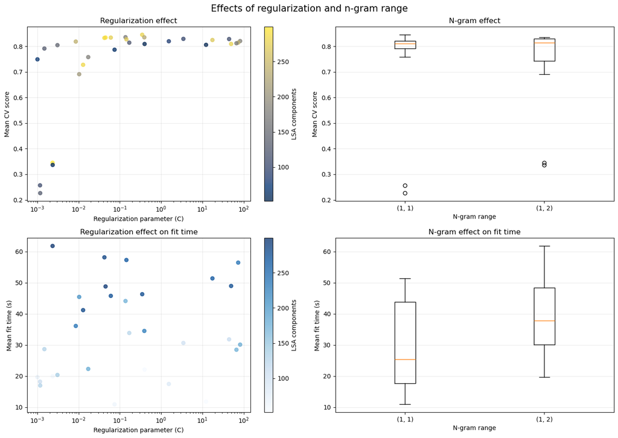

```python
df = results_rsearch_df.copy()
df["ngram_range"] = df["param_vectorizador__ngram_range"].astype(str)
df["n_components"] = df["param_lsa__n_components"].astype(int)
df["C"] = df["param_clasificador__C"].astype(float)

fig, ax = plt.subplots(2, 2, figsize = (14, 10))

metrics = [
    ("mean_test_score", "Mean CV score", "cividis"),
    ("mean_fit_time", "Mean fit time (s)", "Blues")
]

groups = df.groupby("ngram_range", sort=True)
labels = list(groups.groups)

for row, (metric, ylabel, cmap) in enumerate(metrics):

    # C effect
    sc = ax[row, 0].scatter(
        df["C"], df[metric],
        c = df["n_components"], cmap=cmap, alpha=.75
    )
    ax[row, 0].set_xscale("log")
    ax[row, 0].set(
        xlabel = "Regularization parameter (C)",
        ylabel = ylabel,
        title = f"Regularization effect{' on fit time' if row else ''}"
    )
    ax[row, 0].grid(alpha = .25)
    fig.colorbar(sc, ax = ax[row, 0], label = "LSA components")

    # N-gram effect
    ax[row, 1].boxplot(
        [g[metric].values for _, g in groups],
        tick_labels = labels
    )
    ax[row, 1].set(
        xlabel="N-gram range",
        ylabel = ylabel,
        title = f"N-gram effect{' on fit time' if row else ''}"
    )
    ax[row, 1].grid(axis = "y", alpha=.25)

fig.suptitle("Effects of regularization and n-gram range", fontsize=15)
plt.tight_layout()
plt.show()
```

**Análisis**

- El parámetro `C` controla cuánto penaliza `LinearSVC` los errores de clasificación. Los valores pequeños producen una regularización más fuerte, mientras que los valores grandes permiten que el modelo se ajuste más a los datos de entrenamiento.
- Los unigramas representan palabras individuales. Los bigramas incorporan combinaciones de dos palabras, como “cambio climático”, pero aumentan el tamaño de la representación y pueden requerir más tiempo de procesamiento.
- En las configuraciones evaluadas no se observa que aumentar `C` o utilizar bigramas garantice por sí solo un mejor F1 macro. El resultado depende de la combinación entre estos parámetros, el número de componentes LSA y las demás decisiones del pipeline.
- La mejor configuración utilizó unigramas y un valor de `C` cercano a 0,35. Esto indica que, para esta base, las palabras individuales fueron suficientes para alcanzar el mejor resultado entre las combinaciones evaluadas.

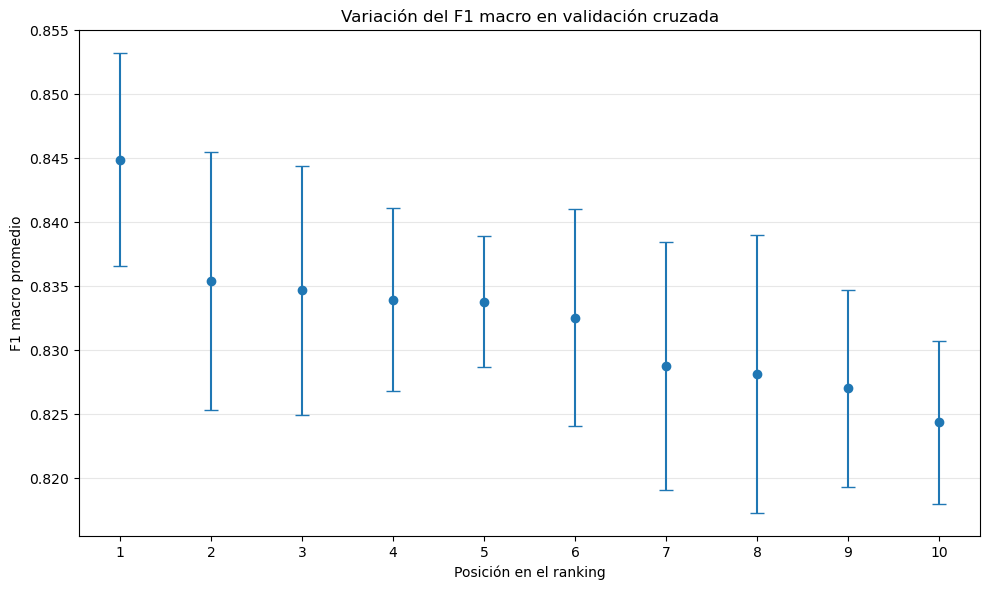

```python
# Desviación estándar del F1 macro para las diez mejores configuraciones
df_top10 = results_rsearch_df.head(10).copy()

plt.figure(figsize=(10, 6))
plt.errorbar(
    x = df_top10["rank_test_score"],
    y = df_top10["mean_test_score"],
    yerr = df_top10["std_test_score"],
    fmt = "o",
    capsize = 5,
)
plt.xlabel("Posición en el ranking")
plt.ylabel("F1 macro promedio")
plt.title("Variación del F1 macro en validación cruzada")
plt.xticks(df_top10["rank_test_score"])
plt.grid(axis="y", alpha=0.3)
plt.tight_layout()
plt.show()
```

Las diez mejores alternativas presentan desviaciones estándar relativamente pequeñas y semejantes. Por tanto, la estabilidad no permite diferenciar claramente una configuración de otra y se conserva la que obtuvo el mayor F1 macro promedio.

# 9. Evaluación del modelo

La configuración con mayor F1 macro en la validación cruzada se evalúa una sola vez sobre el conjunto de prueba reservado desde el inicio.

```python
#Mostrar parametros mejor estimador
best_estimator = random_search.best_estimator_
best_params = random_search.best_params_

#Mostrar parametros mejor estimador
best_params
```

```
{'clasificador__C': np.float64(0.34902252478382495),
 'clasificador__class_weight': 'balanced',
 'lsa__n_components': 278,
 'vectorizador__max_df': np.float64(0.8873938343723312),
 'vectorizador__min_df': 5,
 'vectorizador__ngram_range': (1, 1),
 'vectorizador__sublinear_tf': True}
```

La mejor configuración utilizó únicamente palabras individuales (ngram_range = (1,1)) y conservó los términos presentes en al menos cinco textos, pero no en más del 88,7 % de los documentos. La frecuencia de los términos se ajustó de manera logarítmica (sublinear_tf=True) para reducir la influencia de las palabras repetidas muchas veces. Posteriormente, LSA redujo la representación TF-IDF a 278 componentes semánticos. Finalmente, LinearSVC utilizó un valor de C de aproximadamente 0,35 y balanceo de clases para considerar las diferencias en la cantidad de textos disponibles por ODS. Esta combinación obtuvo el mayor F1 macro durante la validación cruzada.

## 9.1. Predicción sobre el conjunto de prueba

Se generan las predicciones utilizando exclusivamente el conjunto de prueba reservado desde el inicio.

```python
y_pred = best_estimator.predict(X_test)
```

## 9.2. Resultados generales

En esta sección se presenta la matriz de confusión. Cada fila corresponde al ODS real y cada columna al ODS predicho. Los porcentajes se calculan dentro de cada fila para facilitar la comparación entre categorías con diferente cantidad de textos.

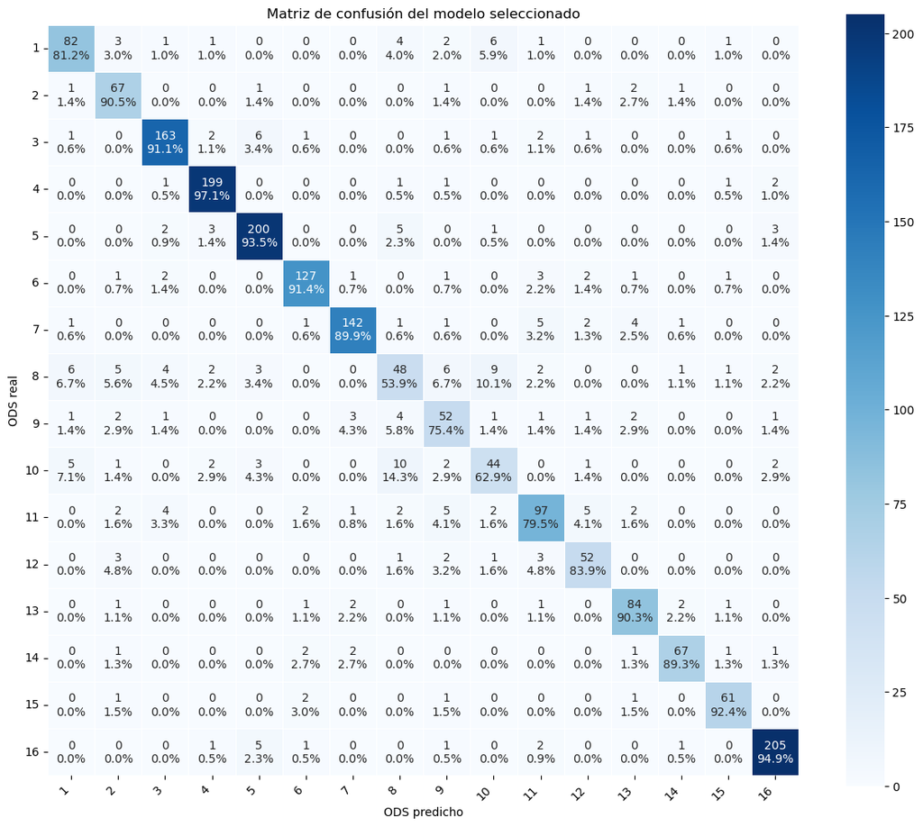

```python
# Calcular la matriz de confusión general
conf_matrix_general = pd.crosstab(
    y_test,
    y_pred,
    rownames = ["ODS real"],
    colnames = ["ODS predicho"],
    margins = True,
)

# Eliminar la fila y columna de totales para la visualización
cm_df = conf_matrix_general.drop(index = "All", columns = "All", errors = "ignore")
cm = cm_df.to_numpy()

# Calcular porcentajes por fila
cm_pct = cm / cm.sum(axis = 1, keepdims = True) * 100
anotaciones = np.empty_like(cm, dtype=object)

for i in range(cm.shape[0]):
    for j in range(cm.shape[1]):
        anotaciones[i, j] = f"{cm[i, j]}\n{cm_pct[i, j]:.1f}%"

plt.figure(figsize = (12, 10))
sns.heatmap(
    cm,
    annot=anotaciones,
    fmt = "",
    cmap = "Blues",
    linewidths = 0.5,
    linecolor = "white",
    square = True,
    xticklabels = cm_df.columns,
    yticklabels = cm_df.index,
)

plt.title("Matriz de confusión del modelo seleccionado")
plt.xlabel("ODS predicho")
plt.ylabel("ODS real")
plt.xticks(rotation = 45, ha = "right")
plt.yticks(rotation = 0)
plt.tight_layout()
plt.show()
```

Se calculan métricas generales de dos maneras:

- **Promedio macro:** todos los ODS tienen el mismo peso, independientemente de su cantidad de textos.
- **Promedio ponderado:** el resultado considera la cantidad de textos de cada ODS.

Como la búsqueda se realizó con F1 macro, esta será la medida principal para evaluar el modelo final.

```python
accuracy = accuracy_score(y_test, y_pred)

precision_macro = precision_score(
    y_test, y_pred, average="macro", zero_division=0
)
recall_macro = recall_score(
    y_test, y_pred, average="macro", zero_division=0
)
f1_macro = f1_score(
    y_test, y_pred, average="macro", zero_division=0
)
f1_ponderado = f1_score(
    y_test, y_pred, average="weighted", zero_division=0
)

print("Resultados sobre el conjunto de prueba:\n")
print(f"Accuracy:        {accuracy:.4f}")
print(f"Precision macro: {precision_macro:.4f}")
print(f"Recall macro:    {recall_macro:.4f}")
print(f"F1 macro:        {f1_macro:.4f}")
print(f"F1 ponderado:    {f1_ponderado:.4f}")
```

```
Resultados sobre el conjunto de prueba:

Accuracy:        0.8747
Precision macro: 0.8442
Recall macro:    0.8482
F1 macro:        0.8452
F1 ponderado:    0.8738
```

**Análisis de las métricas**

El modelo clasificó correctamente el 87,5 % de los textos. El F1 macro de 0,8452 muestra un desempeño favorable al otorgar la misma importancia a todos los ODS. El F1 ponderado fue mayor (0,8738) porque considera la cantidad de textos de cada categoría. Esta diferencia indica que algunos ODS se clasifican mejor que otros, por lo que es necesario complementar estos resultados con el análisis por ODS.

## 9.3. Análisis por ODS

### 9.3.1. Métricas por ODS

Se construye un reporte para examinar el desempeño específico de cada objetivo.

```python
# Construir el reporte de clasificación como una tabla
reporte = classification_report(
    y_test,
    y_pred,
    output_dict = True,
    zero_division = 0,
)

etiquetas_ods = [str(ods) for ods in sorted(y_test.unique())]

detailed_report_df = (
    pd.DataFrame(reporte)
    .T
    .loc[etiquetas_ods, ["precision", "recall", "f1-score", "support"]]
    .reset_index()
    .rename(columns={
        "index": "ODS",
        "precision": "Precision",
        "recall": "Recall",
        "f1-score": "F1-score",
        "support": "Support",
    })
)

detailed_report_df["ODS"] = detailed_report_df["ODS"].astype(int)
detailed_report_df["Support"] = detailed_report_df["Support"].astype(int)
detailed_report_df = detailed_report_df.sort_values(
    by="F1-score", ascending = False
)

detailed_report_df.round(3)
```

|  | ODS | Precision | Recall | F1-score | Support |
| --- | --- | --- | --- | --- | --- |
| 3 | 4 | 0.948 | 0.971 | 0.959 | 205 |
| 15 | 16 | 0.949 | 0.949 | 0.949 | 216 |
| 4 | 5 | 0.917 | 0.935 | 0.926 | 214 |
| 5 | 6 | 0.927 | 0.914 | 0.920 | 139 |
| 6 | 7 | 0.940 | 0.899 | 0.919 | 158 |
| 2 | 3 | 0.916 | 0.911 | 0.913 | 179 |
| 14 | 15 | 0.897 | 0.924 | 0.910 | 66 |
| 13 | 14 | 0.918 | 0.893 | 0.905 | 75 |
| 12 | 13 | 0.866 | 0.903 | 0.884 | 93 |
| 1 | 2 | 0.770 | 0.905 | 0.832 | 74 |
| 0 | 1 | 0.845 | 0.812 | 0.828 | 101 |
| 11 | 12 | 0.800 | 0.839 | 0.819 | 62 |
| 10 | 11 | 0.829 | 0.795 | 0.812 | 122 |
| 8 | 9 | 0.675 | 0.754 | 0.712 | 69 |
| 9 | 10 | 0.677 | 0.629 | 0.652 | 70 |
| 7 | 8 | 0.632 | 0.539 | 0.582 | 89 |

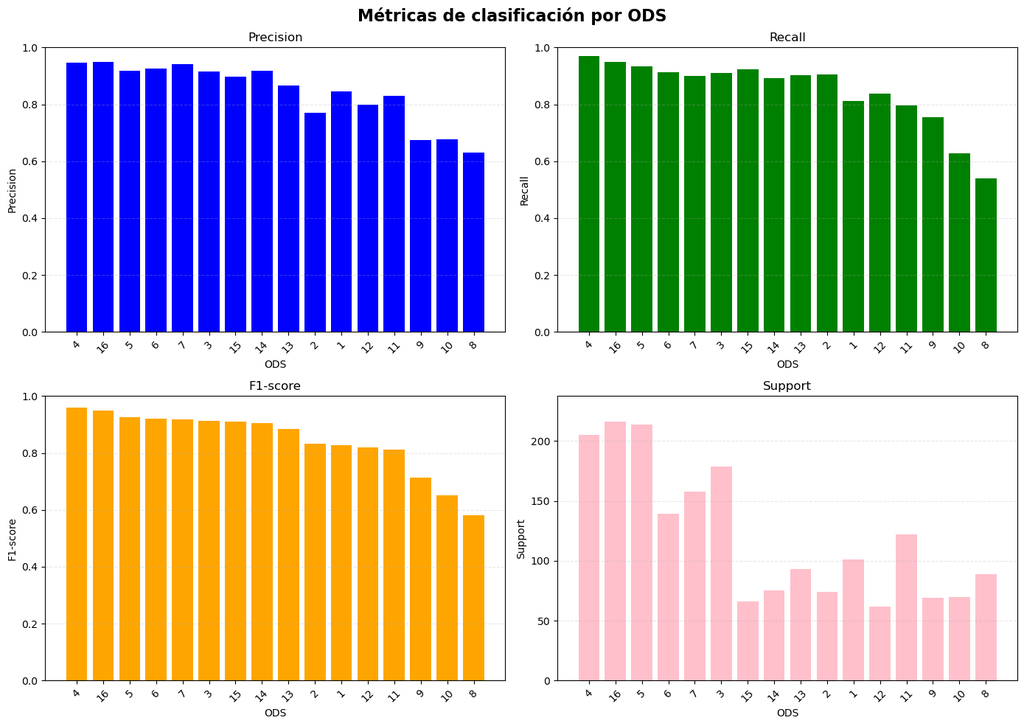

```python
metrics = ["Precision", "Recall", "F1-score", "Support"]
colors = ["blue", "green", "orange", "pink"]

fig, axes = plt.subplots(2, 2, figsize=(14, 10))

for ax, metric, color in zip(axes.flat, metrics, colors):
    values = pd.to_numeric(detailed_report_df[metric], errors="coerce")
    x = range(len(values))

    ax.bar(x, values, color=color)
    ax.set(
        title=metric,
        xlabel="ODS",
        ylabel=metric,
        xticks=x,
        xticklabels=detailed_report_df["ODS"],
    )
    ax.tick_params(axis="x", rotation=45)
    ax.set_ylim(0, 1 if metric != "Support" else values.max() * 1.1)
    ax.grid(axis="y", linestyle="--", alpha=0.3)

fig.suptitle("Métricas de clasificación por ODS", fontsize = 16, fontweight = "bold")
plt.tight_layout()
plt.show()
```

El soporte indica cuántos textos reales pertenecen a cada ODS dentro del conjunto de prueba. A continuación se presenta el ranking de mayor a menor F1.

```python
print('>> Ranking de ODS por F1-score (de mayor a menor):\n')

for ods in detailed_report_df.sort_values(by="F1-score", ascending=False)["ODS"]:
    print(f"-> {ods}: {nombres_ods[int(ods)]}")
```

```
>> Ranking de ODS por F1-score (de mayor a menor):

-> 4: Educación de calidad
-> 16: Paz, justicia e instituciones sólidas
-> 5: Igualdad de género
-> 6: Agua limpia y saneamiento
-> 7: Energía asequible y no contaminante
-> 3: Salud y bienestar
-> 15: Vida de ecosistemas terrestres
-> 14: Vida submarina
-> 13: Acción por el clima
-> 2: Hambre cero
-> 1: Fin de la pobreza
-> 12: Producción y consumo responsables
-> 11: Ciudades y comunidades sostenibles
-> 9: Industria, innovación e infraestructura
-> 10: Reducción de las desigualdades
-> 8: Trabajo decente y crecimiento económico
```

### 9.3.2. Análisis de resultados

El desempeño varía entre los ODS. Para comprender mejor esta diferencia se revisan ejemplos correctamente clasificados y errores del modelo. Los aciertos permiten observar vocabulario temático claro, mientras que los errores ayudan a identificar categorías con contenidos relacionados o ambiguos.

```python
# Consolidar los textos de prueba con sus etiquetas reales y predichas
test_cons_df = pd.DataFrame({
    "texto": X_test,
    "ODS_real": y_test,
    "ODS_predicho": y_pred,
}).reset_index(drop = True)

test_cons_df["clasificacion"] = np.where(
    test_cons_df["ODS_real"] == test_cons_df["ODS_predicho"],
    "Correcta",
    "Incorrecta",
)

# Seleccionar dos aciertos y dos errores de forma reproducible
ejemplos_correctos = test_cons_df[
    test_cons_df["clasificacion"] == "Correcta"
].sample(n=2, random_state=RANDOM_STATE)

ejemplos_incorrectos = test_cons_df[
    test_cons_df["clasificacion"] == "Incorrecta"
].sample(n=2, random_state=RANDOM_STATE)

ejemplos_clasificacion = pd.concat(
    [ejemplos_correctos, ejemplos_incorrectos],
    ignore_index=True,
)

# Mostrar cada ejemplo de forma individual
for _, fila in ejemplos_clasificacion.iterrows():

    texto = str(fila["texto"])

    # Limitar cada ejemplo a 700 caracteres
    if len(texto) > 700:
        texto = texto[:700] + "..."

    print("=" * 100)
    print(f"Clasificación: {fila['clasificacion']}")

    print(
        f"ODS real: {fila['ODS_real']} - "
        f"{nombres_ods[fila['ODS_real']]}"
    )

    print(
        f"ODS predicho: {fila['ODS_predicho']} - "
        f"{nombres_ods[fila['ODS_predicho']]}"
    )

    print("\nTexto:")
    print(textwrap.fill(texto, width=120))
    print()
```

```
====================================================================================================
Clasificación: Correcta
ODS real: 7 - Energía asequible y no contaminante
ODS predicho: 7 - Energía asequible y no contaminante

Texto:
Brasil sigue importando cantidades considerables de carbón y, en menor medida, de electricidad, esta última procedente
en particular de Argentina (EPE, 2008, Costa et al., esto convierte a Brasil en el mercado eléctrico más grande de
América del Sur (IEA, 2009c). Las grandes hidroeléctricas suministran el 72,6% de toda la electricidad, seguida por la
generación termoeléctrica (14,7%) (EPE, 2008).

====================================================================================================
Clasificación: Correcta
ODS real: 14 - Vida submarina
ODS predicho: 14 - Vida submarina

Texto:
Por lo tanto, es posible incorporar algunos aspectos de flexibilidad en los marcos de gestión pesquera. Una vez más,
como parte de ese sistema de gestión pesquera, los pescadores y otras partes interesadas han tenido que estar de acuerdo
en que las medidas de adaptación durante la temporada son beneficiosas y necesarias. Cuanto más rápida y más acertada
sea la acción de gestión para la recuperación, más probable es que pueda haber una respuesta biológica a los esfuerzos
de gestión. Se pueden tomar medidas para recuperar las pesquerías, pero es más probable que la gama de alternativas sea
limitada y que los costos sean más altos (Shertzer y Prager, 2007).

====================================================================================================
Clasificación: Incorrecta
ODS real: 3 - Salud y bienestar
ODS predicho: 5 - Igualdad de género

Texto:
Aunque el conocimiento del VIH/SIDA es bueno en Swazilandia, esto no se correlaciona con el uso de condones. Más del 50
por ciento de los hombres y mujeres adultos que informaron haber tenido más de dos parejas sexuales en el año anterior
usaron un condón la última vez que tuvieron relaciones sexuales (ONUSIDA, 2007). Una de las principales diferencias
identificadas en la propagación en estos países probablemente se deba a los diferentes tipos de VIH.

====================================================================================================
Clasificación: Incorrecta
ODS real: 5 - Igualdad de género
ODS predicho: 8 - Trabajo decente y crecimiento económico

Texto:
Esto es especialmente importante ya que los datos indican que las brechas salariales se están cerrando muy lentamente,
en gran parte debido a la exclusión de las mujeres de los trabajos bien remunerados. Gran parte de la investigación
muestra que, una vez que se emplea, la desigualdad racial y de género se puede atribuir en gran medida a la segregación
laboral. Incluso en los países de ingresos medios en rápido crecimiento, que están experimentando una mejora industrial,
observamos evidencia de desfeminización del empleo manufacturero (Tejani y Milberg20i6). Como resultado de las tasas de
consumo más altas de los grupos de bajos ingresos, los salarios mínimos más altos también estimulan la d...
```

Los ejemplos correctamente clasificados suelen contener expresiones estrechamente relacionadas con su ODS. En los errores aparecen contenidos que pueden vincularse con más de un objetivo, lo cual ayuda a explicar parte de la confusión del modelo. Por ello, los errores no deben interpretarse únicamente como fallas técnicas, sino también como evidencia del solapamiento temático entre algunos ODS.

El balanceo de clases pudo contribuir a que varios ODS con diferente número de textos alcanzaran resultados comparables. Sin embargo, las diferencias finales también dependen de la claridad del vocabulario, el solapamiento entre categorías y la cantidad y diversidad de ejemplos disponibles.

## 9.4. Interpretación cualitativa de LSA

El modelo predictivo utiliza la cantidad de componentes que produjo el mejor F1 macro. Sin embargo, una representación con cientos de componentes resulta difícil de interpretar como conjunto de tópicos. Por esta razón se construye un segundo LSA, utilizado únicamente para la interpretación.

### 9.4.1. Comparación de modelos pequeños

Se comparan modelos de 10, 15 y 20 componentes mediante la varianza explicada acumulada. Esta medida indica qué proporción de la variación de la matriz TF-IDF es resumida por los componentes.

|  | Componentes | Varianza explicada acumulada |
| --- | --- | --- |
| 0 | 10 | 0.0315 |
| 1 | 15 | 0.0413 |
| 2 | 20 | 0.0492 |

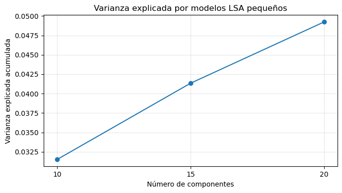

```python
# Transformar entrenamiento con el vectorizador ya ajustado por el mejor pipeline
vect_best = best_estimator.named_steps["vectorizador"]
X_train_tfidf = vect_best.transform(X_train)

comparacion_lsa = []

for componentes in [10, 15, 20]:
    modelo_lsa = TruncatedSVD(
        n_components=componentes,
        random_state=RANDOM_STATE,
    )
    modelo_lsa.fit(X_train_tfidf)

    comparacion_lsa.append({
        "Componentes": componentes,
        "Varianza explicada acumulada": modelo_lsa.explained_variance_ratio_.sum(),
    })

comparacion_lsa_df = pd.DataFrame(comparacion_lsa)
display(comparacion_lsa_df.round(4))

plt.figure(figsize=(7, 4))
plt.plot(
    comparacion_lsa_df["Componentes"],
    comparacion_lsa_df["Varianza explicada acumulada"],
    marker="o",
)
plt.title("Varianza explicada por modelos LSA pequeños")
plt.xlabel("Número de componentes")
plt.ylabel("Varianza explicada acumulada")
plt.xticks([10, 15, 20])
plt.grid(alpha=0.3)
plt.tight_layout()
plt.show()
```

Se seleccionan 15 componentes como una alternativa intermedia: permiten examinar una variedad razonable de relaciones semánticas sin producir una salida demasiado extensa. Esta elección busca facilitar la interpretación, no reemplazar la configuración predictiva seleccionada mediante validación cruzada.

### 9.4.2. Palabras representativas de cinco componentes

```python
# Ajustar el modelo LSA destinado únicamente a la interpretación
lsa_interpretativo = TruncatedSVD(
    n_components=15,
    random_state=RANDOM_STATE,
)

lsa_interpretativo.fit(X_train_tfidf)

# Obtener los términos de TF-IDF
terminos = vect_best.get_feature_names_out()
topicos_interpretados = []

# Analizar los primeros cinco componentes
for numero_topico, componente in enumerate(
    lsa_interpretativo.components_[:5],
    start=1
):
    # Seleccionar las 20 palabras con mayor peso positivo
    indices = componente.argsort()[-20:][::-1]
    palabras = ", ".join(terminos[indices])

    topicos_interpretados.append({
        "Componente": numero_topico,
        "Palabras representativas": palabras,
    })

# Construir la tabla
tabla_topicos = pd.DataFrame(topicos_interpretados)

# Mostrar las palabras completas sin abreviarlas con "..."
with pd.option_context(
    "display.max_colwidth", None,
    "display.width", None
):
    display(tabla_topicos)
```

|  | Componente | Palabras representativas |
| --- | --- | --- |
| 0 | 1 | países, mujeres, desarrollo, pueden, políticas, puede, agua, educación, ocde, mayor, nivel, ejemplo, embargo, salud, servicios, ingresos, género, si, parte, pobreza |
| 1 | 2 | mujeres, hombres, pobreza, ingresos, género, laboral, educación, empleo, niños, trabajo, países, ocde, tasas, años, promedio, desigualdad, tasa, menos, trabajadores, hogares |
| 2 | 3 | derechos, mujeres, derecho, humanos, género, internacional, artículo, igualdad, hombres, violencia, justicia, ley, trabajo, internacionales, tribunales, mujer, penal, política, normas, corte |
| 3 | 4 | educación, estudiantes, escuelas, aprendizaje, atención, escuela, salud, docentes, evaluación, calidad, escolar, formación, alumnos, primaria, enseñanza, profesional, programas, sistema, secundaria, e… |
| 4 | 5 | mujeres, género, hombres, igualdad, políticas, energía, desarrollo, participación, empresas, trabajo, agua, recursos, mujer, laboral, sector, niñas, oportunidades, remunerado, gestión, violencia |

### 9.4.3. Interpretación de los componentes

- **Componente 1 — desarrollo y políticas públicas:** reúne términos generales relacionados con países, desarrollo, políticas y acceso a recursos o servicios.
- **Componente 2 — género, pobreza y trabajo:** integra vocabulario asociado con mujeres, hombres, ingresos, pobreza, empleo, educación y desigualdad.
- **Componente 3 — derechos e igualdad:** concentra términos relacionados con derechos humanos, igualdad de género, violencia, justicia y ley.
- **Componente 4 — educación y calidad:** está representado principalmente por estudiantes, escuelas, aprendizaje, docentes, evaluación y calidad.
- **Componente 5 — igualdad y participación:** combina vocabulario sobre mujeres, género, igualdad, participación, políticas y trabajo.

Los componentes muestran que algunos temas son relativamente claros, mientras que otros comparten vocabulario. Este solapamiento es coherente con la relación existente entre varios ODS y ayuda a explicar algunas confusiones del clasificador.

# 10. Conclusiones y limitaciones

## 10.1. Conclusiones

1. La combinación TF-IDF, LSA y `LinearSVC` permitió construir un clasificador multiclase con un desempeño general satisfactorio. El F1 macro es la métrica principal porque resume el desempeño otorgando el mismo peso a cada ODS.
2. Los ODS con vocabulario temático más específico presentan mejores resultados, mientras que las categorías con contenidos económicos, laborales, urbanos o de desigualdad muestran mayor solapamiento.
3. LSA permitió reducir la representación TF-IDF a componentes semánticos útiles para la clasificación. Un modelo separado y más pequeño facilitó la interpretación de cinco relaciones temáticas.
4. La aplicación de Streamlit demuestra que el modelo puede integrarse en una herramienta sencilla para clasificar nuevos textos.

## 10.2. Limitaciones

- La base no contiene ejemplos del ODS 17, por lo que el modelo no puede predecir esta categoría.
- Los resultados corresponden a las fuentes y al vocabulario presentes en esta base; el desempeño puede cambiar con textos provenientes de otros contextos.
- La búsqueda aleatoria evaluó una cantidad limitada de configuraciones y no garantiza encontrar el mejor modelo posible.

## 10.3. Posibles mejoras

- Incorporar ejemplos adicionales de los ODS con menor desempeño.
- Registrar el documento original de cada texto aumentado para realizar divisiones agrupadas.
- Incorporar datos del ODS 17 para ampliar el alcance del clasificador.

# 10. Referencias y uso de herramientas de IA

- Naciones Unidas. (s. f.). *The 17 Goals*. Sustainable Development Goals. https://sdgs.un.org/goals
- NLTK Project. (s. f.). *NLTK corpus package*. NLTK Documentation. https://www.nltk.org/api/nltk.corpus.html
- Scikit-learn developers. (s. f.). *TfidfVectorizer*. Scikit-learn documentation. https://scikit-learn.org/stable/modules/generated/sklearn.feature_extraction.text.TfidfVectorizer.html
- Scikit-learn developers. (s. f.). *TruncatedSVD*. Scikit-learn documentation. https://scikit-learn.org/stable/modules/generated/sklearn.decomposition.TruncatedSVD.html
- Scikit-learn developers. (s. f.). *LinearSVC*. Scikit-learn documentation. https://scikit-learn.org/stable/modules/generated/sklearn.svm.LinearSVC.html
- Scikit-learn developers. (s. f.). *RandomizedSearchCV*. Scikit-learn documentation. https://scikit-learn.org/stable/modules/generated/sklearn.model_selection.RandomizedSearchCV.html

## Declaración sobre herramientas de apoyo

Se utilizó la aplicación Grammarly como herramienta de apoyo para revisar la ortografía, la gramática y la claridad de la redacción.

# 11. Aplicación en Streamlit

Como componente adicional se desarrolló una aplicación sencilla para ingresar un texto y obtener el ODS predicho por el modelo.

- Repositorio: https://github.com/oskr96/ods_classifier_maia/tree/main
- Aplicación: https://odsclassifiermaia-ufv6npxyhefct94eoq7w58.streamlit.app/